# CEU BA: Introduction to R [Homework]

- How many hotels are from Austria?

```
## [1] 855
```

- What is the rating of the most expensive hotel (based on the price per night)?

```
## [1] 1.5
```

- How many bookings are in 4-star hotels?

```
## [1] 38784
```

- Which country has the highest number of 5-star hotels?

```
## [1] "United Kingdom"
```

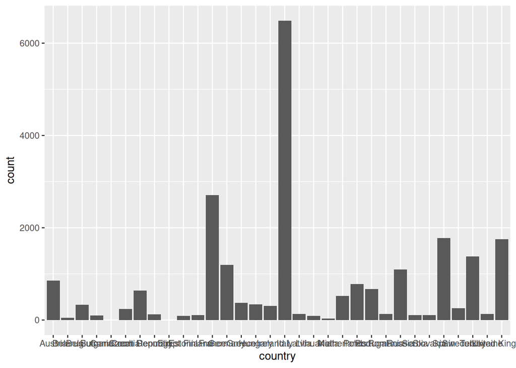

- Flip the coordinates and use the “classic dark-on-light theme”!

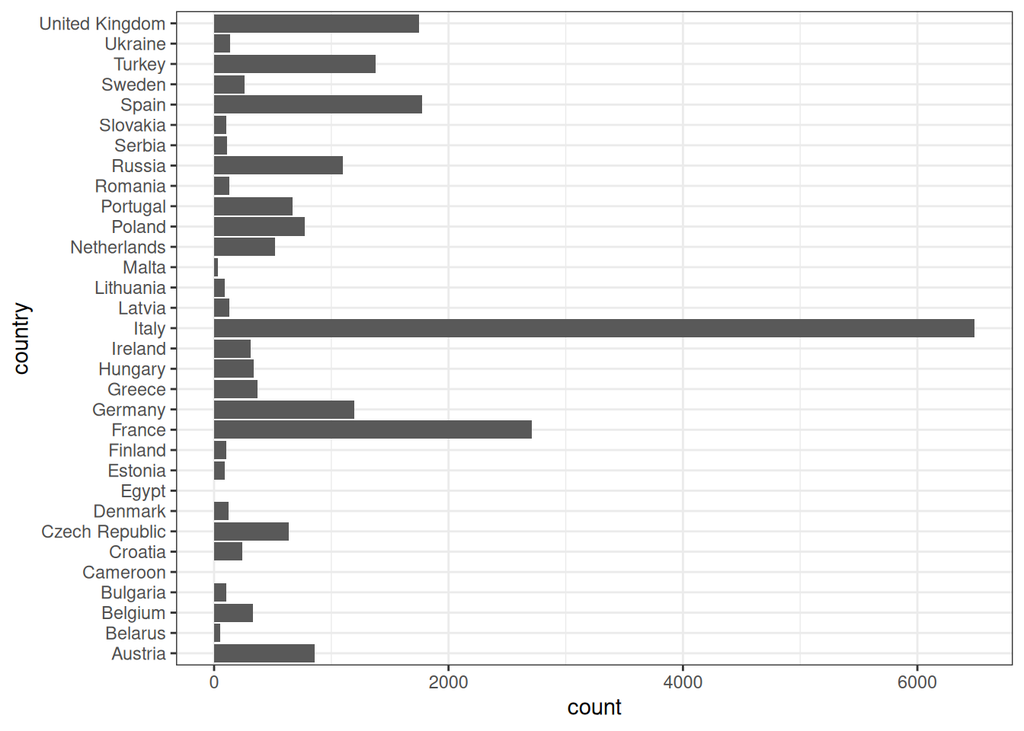

- Drop the Y axis title, and rename the X axis to “Number of hotels”!

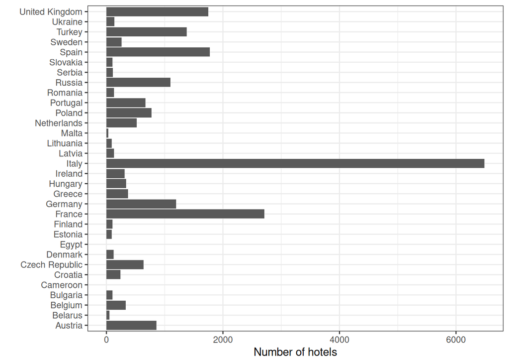

- Count the number of hotels per country!

```
##            country hotels
##  1:    Netherlands    522
##  2:         Greece    369
##  3:          Spain   1774
##  4:         Serbia    111
##  5:        Germany   1196
##  6: United Kingdom   1748
##  7:       Slovakia    104
##  8:        Belgium    333
##  9:        Romania    131
## 10:       Cameroon      1
## 11:        Hungary    340
## 12:        Denmark    121
## 13:        Ireland    309
## 14:        Croatia    241
```

[output cut: 19 more lines]

- Order by alphabet!

```
##            country hotels
##  1:        Austria    855
##  2:        Belarus     51
##  3:        Belgium    333
##  4:       Bulgaria    101
##  5:       Cameroon      1
##  6:        Croatia    241
##  7: Czech Republic    635
##  8:        Denmark    121
##  9:          Egypt      1
## 10:        Estonia     90
## 11:        Finland    103
## 12:         France   2708
## 13:        Germany   1196
## 14:         Greece    369
```

[output cut: 19 more lines]

- Count the number of bookings per country, order by the number of bookings!

```
##            country bookings
##  1:          Egypt        1
##  2:       Cameroon       10
##  3:          Malta      253
##  4:        Belarus      389
##  5:      Lithuania      725
##  6:        Estonia      746
##  7:        Finland      813
##  8:       Bulgaria      840
##  9:       Slovakia      847
## 10:        Denmark      903
## 11:        Ukraine      930
## 12:         Serbia      972
## 13:        Romania     1118
## 14:         Latvia     1144
```

[output cut: 19 more lines]

- Compute the average rating per number of stars! Use the `weighted.mean` function to account for the number of ratings of the hotels, and experiment with the `na.rm` argument. Eliminate `NA`s. Order by stars.

```
##    stars   rating
## 1:   1.0 3.431108
## 2:   1.5 3.323159
## 3:   2.0 3.539957
## 4:   2.5 3.554573
## 5:   3.0 3.822284
## 6:   3.5 4.051862
## 7:   4.0 4.146914
## 8:   4.5 4.298028
## 9:   5.0 4.414935
```

- Plot this computed average rating per stars!

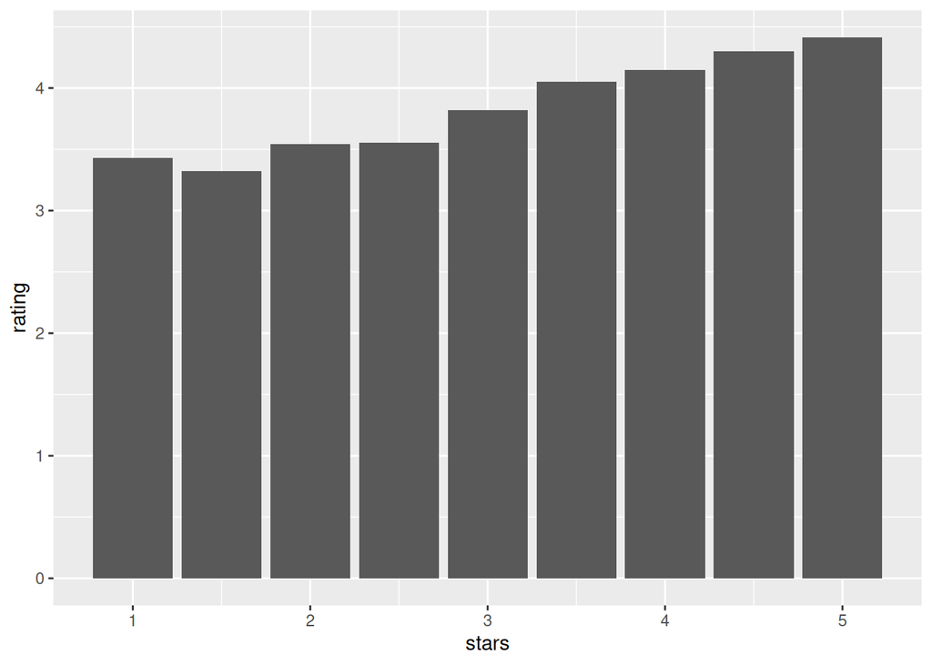

- Make sure that each star category is printed on the X axis!

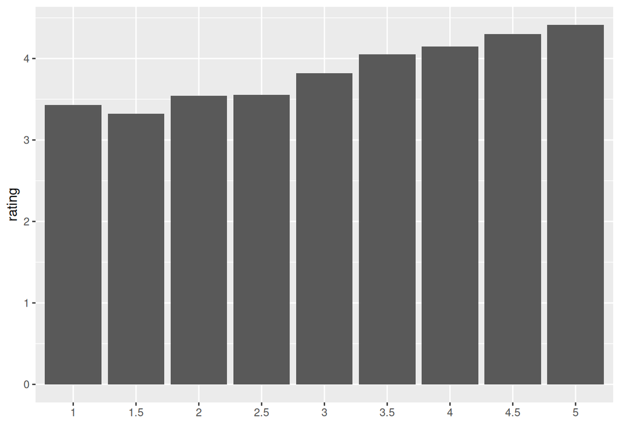

- Create a boxplot on ratings per stars!

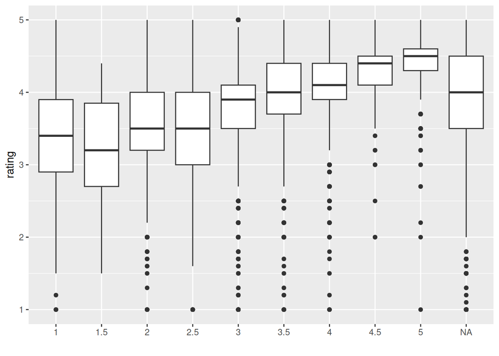

- Create histograms on the nightly prices for each star category! Check out the arguments and disable forcing the same Y axis range for the subplots.

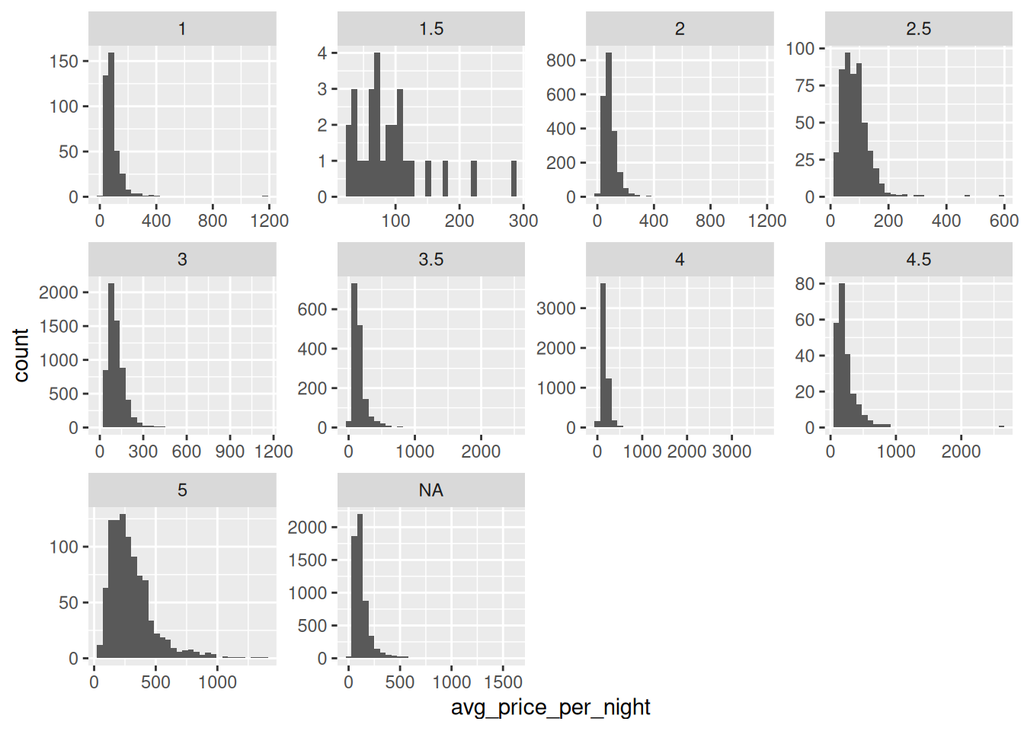